> .

# Project: Investigate a Dataset (noshowappointments-kagglev2-may-2016!)

- Introduction
- Data Wrangling
- Exploratory Data Analysis
- Conclusions

## Introduction

This dataset collects information from 100k medical appointments in Brazil and is focused on the question of whether or not patients show up for their appointment. A number of characteristics about the patient are included in each row

> What factors are important for us to know in order to predict if a patient will show up for their scheduled appointment?. Does some of chronic Diseases is The most common to a specific category

```python
# Use this cell to set up import statements for all of the packages that you
#   plan to use.
import pandas as pd
import numpy as np
import matplotlib.pyplot as plt
import seaborn as sns
%matplotlib inline
```

## Data Wrangling

> We will load in the data, check for cleanliness, and then trim and clean our dataset prepareing it for analysis.

### General Properties

```python
# Load your data and print out a few lines. Perform operations to inspect data
#   types and look for instances of missing or possibly errant data.
df=pd.read_csv('noshowappointments-kagglev2-may-2016.csv')
df.head()
```

|  | PatientId | AppointmentID | Gender | ScheduledDay | AppointmentDay | Age | Neighbourhood | Scholarship | Hipertension | Diabetes | Alcoholism | Handcap | SMS_received | No-show |
| --- | --- | --- | --- | --- | --- | --- | --- | --- | --- | --- | --- | --- | --- | --- |
| 0 | 2.987250e+13 | 5642903 | F | 2016-04-29T18:38:08Z | 2016-04-29T00:00:00Z | 62 | JARDIM DA PENHA | 0 | 1 | 0 | 0 | 0 | 0 | No |
| 1 | 5.589978e+14 | 5642503 | M | 2016-04-29T16:08:27Z | 2016-04-29T00:00:00Z | 56 | JARDIM DA PENHA | 0 | 0 | 0 | 0 | 0 | 0 | No |
| 2 | 4.262962e+12 | 5642549 | F | 2016-04-29T16:19:04Z | 2016-04-29T00:00:00Z | 62 | MATA DA PRAIA | 0 | 0 | 0 | 0 | 0 | 0 | No |
| 3 | 8.679512e+11 | 5642828 | F | 2016-04-29T17:29:31Z | 2016-04-29T00:00:00Z | 8 | PONTAL DE CAMBURI | 0 | 0 | 0 | 0 | 0 | 0 | No |
| 4 | 8.841186e+12 | 5642494 | F | 2016-04-29T16:07:23Z | 2016-04-29T00:00:00Z | 56 | JARDIM DA PENHA | 0 | 1 | 1 | 0 | 0 | 0 | No |

### Data Cleaning

```python
# rename columns that have dictition mistakes
df.rename(columns={'Hipertension':'Hypertension','No-show':'No_show'},inplace=True)
```

```python
df.info()
```

```
<class 'pandas.core.frame.DataFrame'>
RangeIndex: 110527 entries, 0 to 110526
Data columns (total 14 columns):
 #   Column          Non-Null Count   Dtype
---  ------          --------------   -----
 0   PatientId       110527 non-null  float64
 1   AppointmentID   110527 non-null  int64
 2   Gender          110527 non-null  object
 3   ScheduledDay    110527 non-null  object
 4   AppointmentDay  110527 non-null  object
 5   Age             110527 non-null  int64
 6   Neighbourhood   110527 non-null  object
 7   Scholarship     110527 non-null  int64
 8   Hypertension    110527 non-null  int64
 9   Diabetes        110527 non-null  int64
 10  Alcoholism      110527 non-null  int64
 11  Handcap         110527 non-null  int64
 12  SMS_received    110527 non-null  int64
 13  No_show         110527 non-null  object
dtypes: float64(1), int64(8), object(5)
memory usage: 11.8+ MB
```

No missing values

```python
# checking for duplicated rows
sum(df.duplicated())
```

```
0
```

No duplicated rows

```python
# convert date object columns to DateTime and calculate Waiting days as time delta and creat it as a column
df['ScheduledDay']=pd.to_datetime(df['ScheduledDay'],format=('%Y-%m-%dT%H:%M:%S%z')).dt.tz_localize(None)
df['AppointmentDay']=pd.to_datetime(df['AppointmentDay'],format=('%Y-%m-%dT%H:%M:%S%z')).dt.tz_localize(None)
timedelta =(df['AppointmentDay']- df['ScheduledDay']).dt.days
df.insert(5,'Waiting_Days',timedelta) # insert the column at suitable index
```

```python
# check to confirm changes
df.head()
```

|  | PatientId | AppointmentID | Gender | ScheduledDay | AppointmentDay | Waiting_Days | Age | Neighbourhood | Scholarship | Hypertension | Diabetes | Alcoholism | Handcap | SMS_received | No_show |
| --- | --- | --- | --- | --- | --- | --- | --- | --- | --- | --- | --- | --- | --- | --- | --- |
| 0 | 2.987250e+13 | 5642903 | F | 2016-04-29 18:38:08 | 2016-04-29 | -1 | 62 | JARDIM DA PENHA | 0 | 1 | 0 | 0 | 0 | 0 | No |
| 1 | 5.589978e+14 | 5642503 | M | 2016-04-29 16:08:27 | 2016-04-29 | -1 | 56 | JARDIM DA PENHA | 0 | 0 | 0 | 0 | 0 | 0 | No |
| 2 | 4.262962e+12 | 5642549 | F | 2016-04-29 16:19:04 | 2016-04-29 | -1 | 62 | MATA DA PRAIA | 0 | 0 | 0 | 0 | 0 | 0 | No |
| 3 | 8.679512e+11 | 5642828 | F | 2016-04-29 17:29:31 | 2016-04-29 | -1 | 8 | PONTAL DE CAMBURI | 0 | 0 | 0 | 0 | 0 | 0 | No |
| 4 | 8.841186e+12 | 5642494 | F | 2016-04-29 16:07:23 | 2016-04-29 | -1 | 56 | JARDIM DA PENHA | 0 | 1 | 1 | 0 | 0 | 0 | No |

```python
df['Waiting_Days'].unique()
```

```
array([ -1,   1,   2,   0,   3,   8,  28,   9,  22,  10,  17,  16,  13,
        27,  23,  20,  14,  15,  21,  42,  29,  30,  41,  31,  55,  44,
        45,  38,  36,  37,  43,  49,  59,  51,  52,  64,  66,  90,  65,
        83,  77,  86, 114, 108,  62,  69,  71,  56,  57,  50,  58,  40,
        48,  72,  63,  19,  32,  33,   5,  34,  35,  11,  12,  39,  46,
         7,   4,   6,  24,  25,  47,  26,  18,  60,  54,  61, 175,  53,
        76,  68,  82,  75,  88,  80, 102,  78,  67,  74,  84, 111,  -2,
        79,  85,  97,  93, 141, 154, 161, 168, 103, 132, 124,  95,  87,
        89, 150, 125, 126, 110, 118,  73,  70,  81, 107, 109, 101, 121,
       100, 104,  91,  96,  92, 106,  94,  -7, 138, 131, 178, 116, 145,
       122], dtype=int64)
```

```python
(df['Waiting_Days']<-1).value_counts() , (df['Waiting_Days']>150).value_counts()
```

```
(False    110522
 True          5
 Name: Waiting_Days, dtype: int64,
 False    110472
 True         55
 Name: Waiting_Days, dtype: int64)
```

remove the outliers rows > 150 Days< -1 **"some of cleaning issue"**

```python
# remove outliers of waitng days
df=df[(df['Waiting_Days']<150)]
```

```python
# remove outliers of waitng days
df=df[(df['Waiting_Days']>=-1)]
```

```python
#check for changes
df.info()
```

```
<class 'pandas.core.frame.DataFrame'>
Int64Index: 110466 entries, 0 to 110526
Data columns (total 15 columns):
 #   Column          Non-Null Count   Dtype
---  ------          --------------   -----
 0   PatientId       110466 non-null  float64
 1   AppointmentID   110466 non-null  int64
 2   Gender          110466 non-null  object
 3   ScheduledDay    110466 non-null  datetime64[ns]
 4   AppointmentDay  110466 non-null  datetime64[ns]
 5   Waiting_Days    110466 non-null  int64
 6   Age             110466 non-null  int64
 7   Neighbourhood   110466 non-null  object
 8   Scholarship     110466 non-null  int64
 9   Hypertension    110466 non-null  int64
 10  Diabetes        110466 non-null  int64
 11  Alcoholism      110466 non-null  int64
 12  Handcap         110466 non-null  int64
 13  SMS_received    110466 non-null  int64
 14  No_show         110466 non-null  object
dtypes: datetime64[ns](2), float64(1), int64(9), object(3)
memory usage: 13.5+ MB
```

```python
df.describe()
```

|  | PatientId | AppointmentID | Waiting_Days | Age | Scholarship | Hypertension | Diabetes | Alcoholism | Handcap | SMS_received |
| --- | --- | --- | --- | --- | --- | --- | --- | --- | --- | --- |
| count | 1.104660e+05 | 1.104660e+05 | 110466.000000 | 110466.000000 | 110466.000000 | 110466.000000 | 110466.000000 | 110466.000000 | 110466.000000 | 110466.000000 |
| mean | 1.474849e+14 | 5.675576e+06 | 9.103951 | 37.075734 | 0.098293 | 0.196957 | 0.071823 | 0.030417 | 0.022224 | 0.320868 |
| std | 2.560752e+14 | 7.028679e+04 | 14.834690 | 23.105945 | 0.297711 | 0.397701 | 0.258196 | 0.171731 | 0.161479 | 0.466812 |
| min | 3.921784e+04 | 5.156414e+06 | -1.000000 | -1.000000 | 0.000000 | 0.000000 | 0.000000 | 0.000000 | 0.000000 | 0.000000 |
| 25% | 4.172457e+12 | 5.640340e+06 | -1.000000 | 18.000000 | 0.000000 | 0.000000 | 0.000000 | 0.000000 | 0.000000 | 0.000000 |
| 50% | 3.173184e+13 | 5.680610e+06 | 3.000000 | 37.000000 | 0.000000 | 0.000000 | 0.000000 | 0.000000 | 0.000000 | 0.000000 |
| 75% | 9.438963e+13 | 5.725553e+06 | 14.000000 | 55.000000 | 0.000000 | 0.000000 | 0.000000 | 0.000000 | 0.000000 | 1.000000 |
| max | 9.999816e+14 | 5.790484e+06 | 145.000000 | 115.000000 | 1.000000 | 1.000000 | 1.000000 | 1.000000 | 4.000000 | 1.000000 |

```python
age=(df['Age']==-1)
```

```python
# Remove the age=-1 rows
df=df.drop(index=df.loc[age,'Age'].index)
```

Removing the value of minumum value in the age column = -1 from our data as it a pointless value

## Exploratory Data Analysis

Now We're ready to move on to exploration. Compute statistics and create visualizations

### A quick overview on our dataset using hist function to numeric specific columns

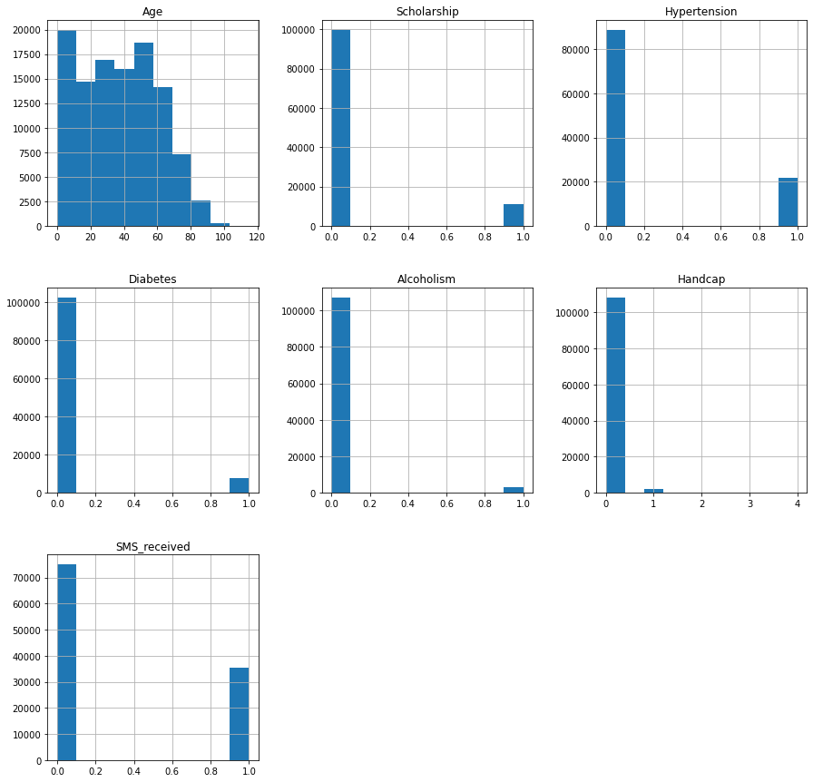

```python
df.hist(figsize=(15,15),column=['Age','Scholarship','Hypertension','Diabetes','Alcoholism','Handcap','SMS_received']);
```

the number of Alcoholism and Handcap is very small

### What is the effect of waiting time on attendance?

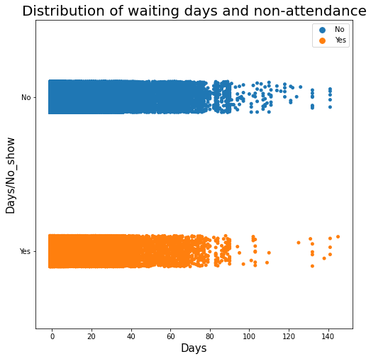

```python
plt.figure(figsize=(8,8));
sns.stripplot(data=df,x='Waiting_Days',y='No_show',hue='No_show' );
plt.title('Distribution of waiting days and non-attendance',fontsize=20)
plt.xlabel('Days',fontsize=15)
plt.ylabel('Days/No_show',fontsize=15)
plt.legend()
plt.show();
```

I tried to observe the effect of waiting days on the non-attendance but that it Contrary to what I expected nearly from visualization non attendance **yes** is smaller than **no** amonge Elongation of waiting days

```python
# define function to facilitate our counts
def count_values(df,column=None):
    return df[column].value_counts()
```

```python
# Condition establishment for show and no show patients
show=df['No_show']=='No'
no_show=df['No_show']=='Yes'
```